# covidreport

PANG KAM HING

2022-08-06

## Introduction

COVID-19 has become a global pandemic. Analyzing the patterns can give a deeper understanding of the virus. the report cites Johns Hopkins github site, Importing the time series of COVID-19 case(US and global).

## Library

```r
library(tidyverse)
library(tinytex)
library(lubridate)
```

```r
library(cowplot)
```

## Importing Data

```r
URL = 'https://raw.githubusercontent.com/CSSEGISandData/COVID-19/master/csse_covid_19_data/csse_covid_19_time_series/'
time_series_covid19_confirmed_US.csv = str_c(URL,'time_series_covid19_confirmed_US.csv')
time_series_covid19_confirmed_global.csv = str_c(URL,'time_series_covid19_confirmed_global.csv')
time_series_covid19_deaths_US.csv = str_c(URL,'time_series_covid19_deaths_US.csv')
time_series_covid19_deaths_global.csv = str_c(URL,'time_series_covid19_deaths_global.csv')
time_series_covid19_recovered_global.csv=str_c(URL,'time_series_covid19_recovered_global.csv')
CUS=read.csv(time_series_covid19_confirmed_US.csv)
CGL=read.csv(time_series_covid19_confirmed_global.csv)
DUS=read.csv(time_series_covid19_deaths_US.csv)
DGL=read.csv(time_series_covid19_deaths_global.csv)
```

## Data cleaning

First,To reduce unnecessary variables, in this report we mainly study the relationship between latitude , case and Case fatality ratio .

```r
CUS<-CUS%>%select(-UID,-iso2,-iso3,-code3,-FIPS,-Admin2,-Province_State,-Country_Region)%>%pivot_longer(cols= starts_with('X'),names_to ='Date',values_to = "Case_Number")%>%mutate(Date=as.Date(gsub('X','',Date),format='%m.%d.%y'))
CGL<-CGL%>%pivot_longer(cols= starts_with('X'),names_to ='Date',values_to = "Case_Number")%>%mutate(Date=as.Date(gsub('X','',Date),format='%m.%d.%y'))
DUS<-DUS%>%select(-UID,-iso2,-iso3,-code3,-FIPS,-Admin2,-Province_State)%>%pivot_longer(cols= starts_with('X'),names_to ='Date',values_to = "Case_Number")%>%mutate(Date=as.Date(gsub('X','',Date),format='%m.%d.%y'))
DGL<-DGL%>%pivot_longer(cols= starts_with('X'),names_to ='Date',values_to = "Case_Number")%>%mutate(Date=as.Date(gsub('X','',Date),format='%m.%d.%y'))
```

## Data Transfer for Case Fatality ratio plot

Summarize the US and Global COIVD-19 case by date. In order to avoid too few samples and too many fluctuations in the early stage of the epidemic, we filter the top 10,0000 cases . After this,We citing Case fatality ratio(CFR) by World Health Organization,to create fatality ration by date in US and global. [The World Health Organization states](https://www.who.int/news-room/commentaries/detail/estimating-mortality-from-covid-19)

$$Case\ Fatality\ ratio(CFR,in\%) = \frac{Number\ of\ deaths\ from
disease}{Number\ of\ comfirmed\ cases \ of\ individuals} \ \times 100$$

We would cumulatively use this CFR function.

```r
USCASE <-CUS%>%group_by(Date)%>%summarise(US_case=sum(Case_Number))
GLCASE <-CGL%>%group_by(Date)%>%summarise(GL_case=sum(Case_Number))
USDIED<-DUS%>%group_by(Date)%>%summarise(USD_case=sum(Case_Number))
GLDIED<-DGL%>%group_by(Date)%>%summarise(GLD_case=sum(Case_Number))
USCASE<-merge(USDIED,USCASE,by="Date")%>% filter(US_case>100000)
GLCASE<-merge(GLDIED,GLCASE,by="Date")%>%filter(GL_case>100000)
USCFR<-USCASE%>%mutate(US_CFR=USD_case*100/US_case)
GLCFR<-GLCASE%>%mutate(GL_CFR=GLD_case*100/GL_case)
```

## Plotting US and Global case by Date

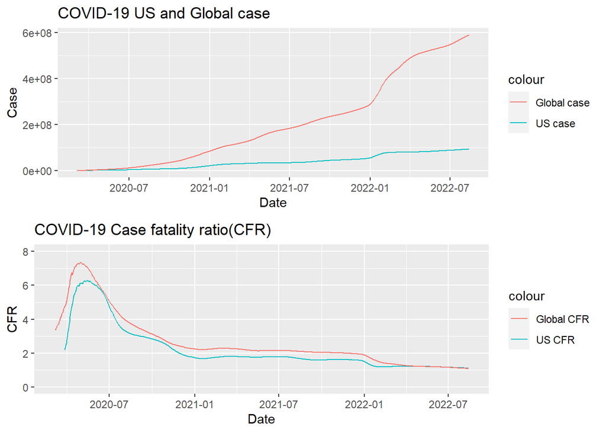

```r
CASE_plot<-ggplot()+geom_line(data=USCASE,aes(Date,US_case,color="US case",))+
  geom_line(data=GLCASE,aes(Date,GL_case,color="Global case"))+
  ylab("Case")+ggtitle("COVID-19 US and Global case")
CRF_plot<-ggplot()+geom_line(data=USCFR,aes(Date,US_CFR,color="US CFR"))+
  geom_line(data=GLCFR,aes(Date,GL_CFR,color="Global CFR"))+ylab("CFR")+ggtitle("COVID-19 Case fatality ratio(CFR)")+scale_y_continuous(limits = c(0, 8))
plot_grid(CASE_plot,CRF_plot,nrow=2)
```

## Tiding Relationship about COVID-19 CFR with latitude in USA

```r
LCase <-CUS%>%group_by(Lat)%>%summarise(C_Lat=sum(Case_Number))
LDied<-DUS%>%group_by(Lat)%>%summarise(D_Lat=sum(Case_Number))
LCFR<-merge(LDied,LCase,by="Lat")%>%mutate(L_CFR=D_Lat*100/C_Lat)
```

## Ploting the relationship between CFR with latitude:

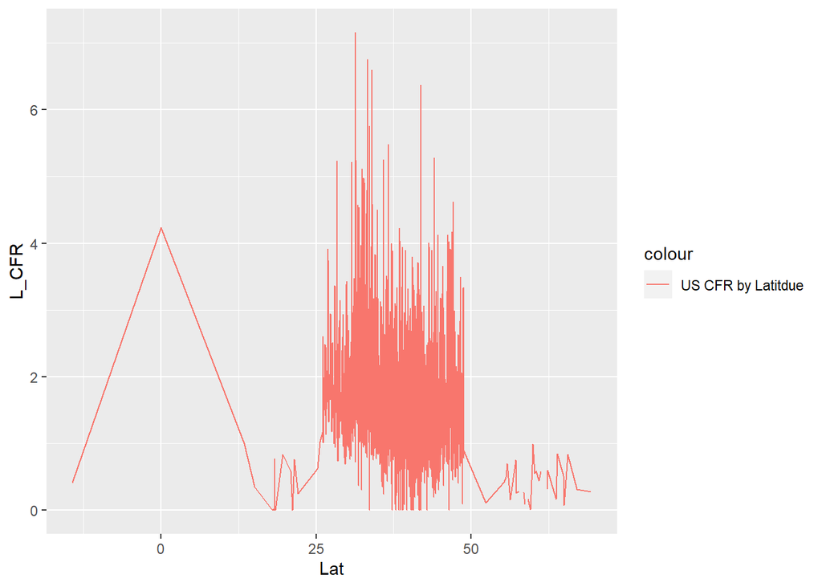

```r
ggplot(LCFR,aes(Lat,L_CFR,color="US CFR by Latitdue"))+geom_line()
```

## Modeling US CFR

Assuming that the accumulated by date that known cases can be fitted with a polynomial function.we can assume:
$$CFR\approx\frac{Case}{b*Case^{1.5}+a*Case+c} \ \times 100$$

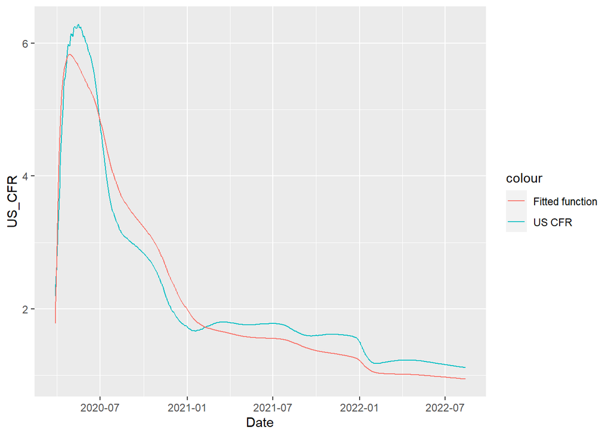

```r
DATA=mutate(USCFR,input=US_case/1000000)
MODEL <-nls(US_CFR ~100*input/(b*input^1.5+a*input+c),start=list(a=1,b=1,c=1),data=DATA,algorithm ="port" )
ggplot()+geom_line(data=USCFR,aes(Date,US_CFR,color="US CFR"))+geom_line(data=USCASE,aes(Date,fitted(MODEL),color="Fitted function"))
```

```r
summary(MODEL)
```

```
##
## Formula: US_CFR ~ 100 * input/(b * input^1.5 + a * input + c)
##
## Parameters:
##   Estimate Std. Error t value Pr(>|t|)
## a   0.7868     0.3064   2.567   0.0104 *
## b  10.9061     0.1239  88.052   <2e-16 ***
## c   5.4556     0.1897  28.753   <2e-16 ***
## ---
## Signif. codes:  0 '***' 0.001 '**' 0.01 '*' 0.05 '.' 0.1 ' ' 1
##
## Residual standard error: 0.3033 on 867 degrees of freedom
##
## Algorithm "port", convergence message: relative convergence (4)
```

This model are good fitted the CFR.We set the maximum degree of this polynomial to 1.5, which works well. This polynomial hyperparameter may be related to the rate of infection and the ability of the virus to mutate.

## Bias

Firstly,This known COVID-19 cases are not total cases on the world,the known COVID-19 cases are according to local nucleic acid and testing policies.In the early days of the epidemic, there were not enough nucleic acid tests in the world. And now, the rate of voluntary nucleic acid testing may be lower.when died cases better detection,these cases would increase the Case fatality ratio,But it will be overestimated than reality.

Secondly,Testing policies vary around the world,If we get in conclusion about the US CFR is lower the world,then We can not directly say that the true death rate is like this.Because the US testing policies may stricter than other countries,Make the denominator of CFR larger.

## Reference:

COVID-19 Johns Hopkins github Data source:

## https://github.com/CSSEGISandData/COVID-19/tree/master/csse_covid_19_data/csse_covid_19_time_series

WHO status Case fatality ratio(CFR):

https://www.who.int/news-room/commentaries/detail/estimating-mortality-from-covid-19